# MortgageMarketAnalysis

2022-06-16

The goal of this analysis is to compare relative performance of mortgage bonds to US gov’t bonds in order to see how the FOMC rate hike on 6/15/2022 and the abysmal housing report on 6/16/2022 are affecting the mortgage markets. In this analysis, I will import the data (Excel sheet attached), perform some basic exploratory data analysis, and then from the data analysis, decide on a feasible statistical method to extract insight into the current mortgage market.

First we begin by loading in the necessary data and libraries. Additionally, I filter out unneeded columns that are blank and limit the data to returns from 2022.

```r
# Clear the Workspace
rm(list=ls())

library(tidyverse)
library(readxl)
library(devtools)

rate_mbs_selloff <- read_excel("rate mbs selloff.xlsx")

#filter out NA columns by position
data1 <- rate_mbs_selloff %>% select(
  1,2,5,8,11,14,17
)

#only want 2022 data
data1 <- data1 %>% slice(1:116)#116

#check to make sure it works
View(data1)
```

After this is done, we can perform exploratory data analysis and plotting of our data. The main focus of our EDA will be to explore the correlation of the yields.

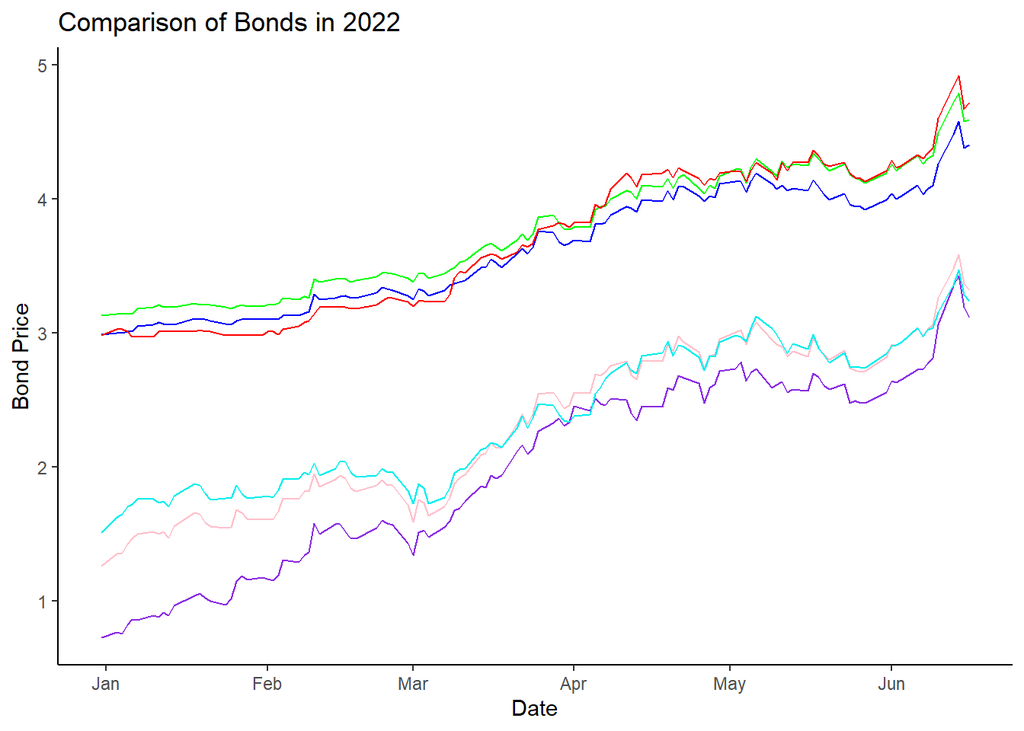

```r
#start EDA by plotting all line with ggplot2
library(ggplot2)

plot1 <- ggplot()+
  geom_line(data = data1,
            aes(x = Date, y = us_govt_2y),
            color='blueviolet')+

  geom_line(data = data1,
            aes(x = Date, y = us_govt_5y),
            color='pink')+

  geom_line(data = data1,
            aes(x = Date, y = us_govt_10y),
            color='cyan2')+

  geom_line(data = data1,
            aes(x = Date, y = fannie_4cpn),
            color='blue')+

  geom_line(data = data1,
            aes(x = Date, y = Mid_Yield_To_Convention),
            color='green')+

  geom_line(data = data1,
            aes(x = Date, y = fannie_5cpn),
            color='red')+

  theme_classic()+
  labs(title = 'Comparison of Bonds in 2022')+
  xlab('Date')+
  ylab('Bond Price')

plot1
```

Looking at the plot above, it appears that the bonds might be correlated. In this case, principal component analysis will be a helpful statistical method to use, as it is a dimension-reduction tool that is used to reduce a large set of possibly correlated variables into a smaller set number of uncorrelated variables(called the principal components). These principal components will explain most of the variation of the large set of variables. The first principle component explains the maximum percentage of the total variance of interest change. The second principal component is designed to be linearly independent of the first and explains the maximum percentage of the remaining variance, and so on and so forth.

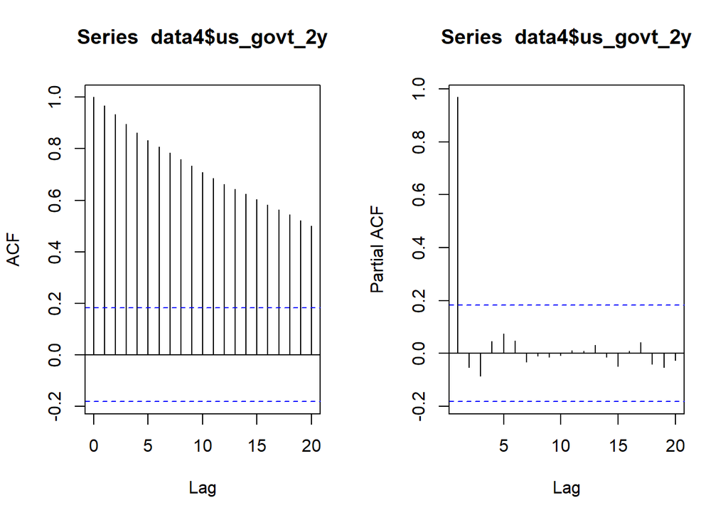

```r
#remove dates to look at data
data4 <- data1 %>% select(
  2,3,4,5,6,7
)

#we can run acf and partial acf test on the 2 year Treasury Note and the Fannie 4% coupon to see if the data is non stationary
par(mfrow=c(1,2))
acf(data4$us_govt_2y)
pacf(data4$us_govt_2y)
```

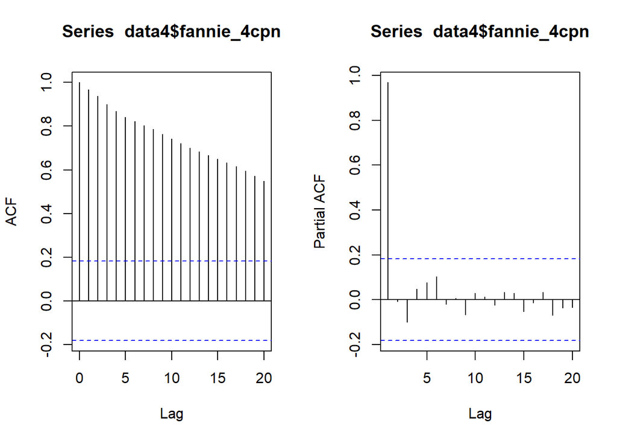

```r
par(mfrow=c(1,2))
acf(data4$fannie_4cpn)
pacf(data4$fannie_4cpn)
```

```r
library(tseries)
adf.test(data4$fannie_4cpn)
```

```
##
##  Augmented Dickey-Fuller Test
##
## data:  data4$fannie_4cpn
## Dickey-Fuller = -2.1884, Lag order = 4, p-value = 0.4984
## alternative hypothesis: stationary
```

```r
library(urca)

test1 <- ur.df(data4$fannie_4cpn, type='drift',lags = 4)
summary(test1)
```

```
##
## ###############################################
## # Augmented Dickey-Fuller Test Unit Root Test #
## ###############################################
##
## Test regression drift
##
##
## Call:
## lm(formula = z.diff ~ z.lag.1 + 1 + z.diff.lag)
##
## Residuals:
##       Min        1Q    Median        3Q       Max
## -0.133635 -0.032218  0.002744  0.028258  0.104783
##
## Coefficients:
##              Estimate Std. Error t value Pr(>|t|)
## (Intercept)  0.021322   0.041220   0.517    0.606
## z.lag.1     -0.009307   0.011377  -0.818    0.415
## z.diff.lag1 -0.027299   0.090820  -0.301    0.764
## z.diff.lag2 -0.044436   0.089422  -0.497    0.620
## z.diff.lag3 -0.082354   0.083461  -0.987    0.326
## z.diff.lag4  0.100773   0.083646   1.205    0.231
##
## Residual standard error: 0.0485 on 105 degrees of freedom
## Multiple R-squared:  0.03452,    Adjusted R-squared:  -0.01146
## F-statistic: 0.7508 on 5 and 105 DF,  p-value: 0.5873
##
##
## Value of test-statistic is: -0.8181 2.9874
##
## Critical values for test statistics:
##       1pct  5pct 10pct
## tau2 -3.46 -2.88 -2.57
## phi1  6.52  4.63  3.81
```

Upon running this Dickey-Fuller unit root with drift test, it can be seen that interpreting the test is time consuming to determine if there is drift involved in the data. Therefore, I used a function that can be found at https://gist.github.com/hankroark/968fc28b767f1e43b5a33b151b771bf9 to interpret the output.

```r
source("~/interp_urdf.R")

interp_urdf(test1, level = "5pct")
```

```
## ========================================================================
## At the 5pct level:
## The model is of type drift
## tau2: The first null hypothesis is not rejected, unit root is present
## phi1: The second null hypothesis is not rejected, unit root is present
##       and there is no drift.
## ========================================================================
```

As can be seen, this shows that the Fannie 4% coupon bond contains no drift.

Based on the analysis above, principle component analysis appears to be an useful model. This allows us to reduce the dimensionality of the different bonds and then analyze how the bond prices are functioning related to each other. The principal components generated by the model will be able to explain the vast majority of the yield curve while remaining uncorrelated to each other.

The graph above shows that the bonds shown above appear to be highly correlated. This is a problem if we would like to perform principal component analysis as PCA requires a stationary time-series, which means that a invariant of the market must be produced. According to Meucci(2005), taking the first difference will be sufficient. Therefore, we can establish that Rt,k = yield i,k - yield i-1,k as the yield return of maturity k at time t.

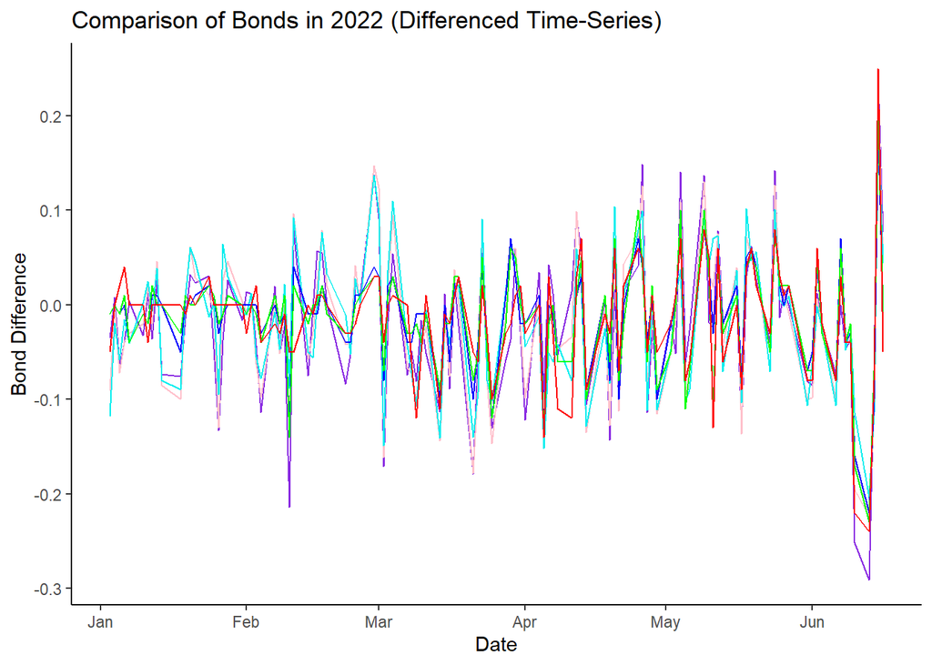

```r
#remove dates to difference the series
data3 <- data1 %>% select(
  2,3,4,5,6,7
)
data3 <- data.frame(data3)

#difference the series once
returns <- as.data.frame(lapply(data3, diff, lag=1))
returns <- data.frame(returns)

#remove last row of data1 as we have a differenced time-series now
data1 <- data1 %>% slice(1:115)#115

#add the date column back to the dataset
returns$Date <- data1$Date


#plot the data to check that it worked
plot2 <- ggplot()+
  geom_line(data = returns,
            aes(x = Date, y = us_govt_2y),
            color='blueviolet')+

  geom_line(data = returns,
            aes(x = Date, y = us_govt_5y),
            color='pink')+

  geom_line(data = returns,
            aes(x = Date, y = us_govt_10y),
            color='cyan2')+

  geom_line(data = returns,
            aes(x = Date, y = fannie_4cpn),
            color='blue')+

  geom_line(data = returns,
            aes(x = Date, y = Mid_Yield_To_Convention),
            color='green')+

  geom_line(data = returns,
            aes(x = Date, y = fannie_5cpn),
            color='red')+

  theme_classic()+
  labs(title = 'Comparison of Bonds in 2022 (Differenced Time-Series)')+
  xlab('Date')+
  ylab('Bond Difference')

plot2
```

We need to confirm the data is now stationary with an ADF test.

```r
adf.test(returns$fannie_4cpn)
```

```
##
##  Augmented Dickey-Fuller Test
##
## data:  returns$fannie_4cpn
## Dickey-Fuller = -5.851, Lag order = 4, p-value = 0.01
## alternative hypothesis: stationary
```

The p-value = 0.01, meaning we reject the null hypothesis that the data is non-stationary.

Next, we can check the yield return matrix for any kind of correlation. We expect to see a correlation in that if a bond with two year maturity starts to pay less, there should be an impact on a bond with 5 year maturity. The larger the difference in maturities, the lower the correlation should be. Additionally, it is good to look at the matrix to make sure there is some correlation, else PCA will not help reduce dimensionality.

```r
#remove dates to look at correlation
cor.returns <- returns %>% select(
  1,2,3,4,5,6
)

options(digits = 2) #better visualization
cor(cor.returns) #correlation matrix of yield returns
```

```
##                         us_govt_2y us_govt_5y us_govt_10y fannie_4cpn
## us_govt_2y                    1.00       0.93        0.82        0.84
## us_govt_5y                    0.93       1.00        0.95        0.88
## us_govt_10y                   0.82       0.95        1.00        0.85
## fannie_4cpn                   0.84       0.88        0.85        1.00
## Mid_Yield_To_Convention       0.82       0.85        0.81        0.97
## fannie_5cpn                   0.73       0.75        0.72        0.86
##                         Mid_Yield_To_Convention fannie_5cpn
## us_govt_2y                                 0.82        0.73
## us_govt_5y                                 0.85        0.75
## us_govt_10y                                0.81        0.72
## fannie_4cpn                                0.97        0.86
## Mid_Yield_To_Convention                    1.00        0.90
## fannie_5cpn                                0.90        1.00
```

As can be seen by a quick glance, this matrix is highly correlated. This confirms that Treasury notes and mortgage rates are highly correlated and will generally move in tandem with each other. This is an economically sound principle, as it has been observed that interest rates tend to become more synchronized in a distressed market environment, as the current market is slowly becoming.

```r
model <- prcomp(cor.returns, scale = TRUE, center = TRUE)
summary(model)
```

```
## Importance of components:
##                          PC1   PC2    PC3    PC4     PC5     PC6
## Standard deviation     2.288 0.648 0.4279 0.3488 0.16655 0.11599
## Proportion of Variance 0.872 0.070 0.0305 0.0203 0.00462 0.00224
## Cumulative Proportion  0.872 0.942 0.9729 0.9931 0.99776 1.00000
```

```r
# first principal component sign flip so it's an upward shift in yield
model$x[,1] <- -model$x[,1]
# also have to flip sign for eigenvector
model$rotation[,1] <- -model$rotation[,1]

# how much variance is captured in first n eigenvectors?
variance1 <- cumsum(model$sdev^2)/sum(model$sdev^2)
print(variance1)
```

```
## [1] 0.87 0.94 0.97 0.99 1.00 1.00
```

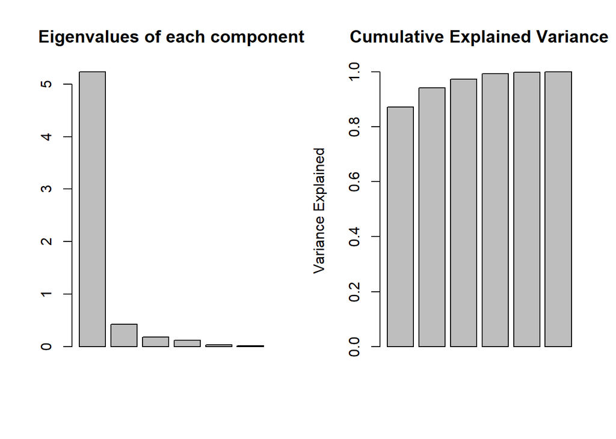

```r
par(mfrow = c(1,2))
barplot(model$sdev^2, main = 'Eigenvalues of each component')
barplot(cumsum(model$sdev^2)/sum(model$sdev^2), main = 'Cumulative Explained Variance', ylab = 'Variance Explained')
```

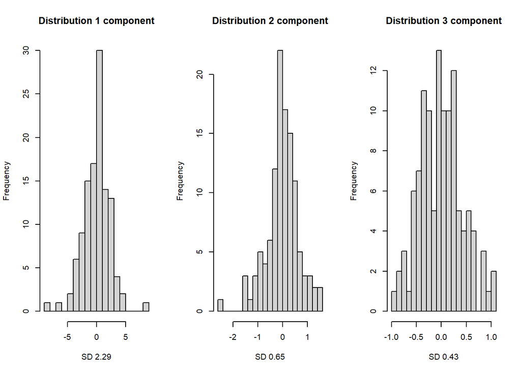

```r
par(mfrow = c(1,3))
hist(model$x[,1], breaks = 20, main = 'Distribution 1 component', xlab = paste('SD', round(model$sdev[1],2)))
hist(model$x[,2], breaks = 20, main = 'Distribution 2 component', xlab = paste('SD', round(model$sdev[2],2)))
hist(model$x[,3], breaks = 20, main = 'Distribution 3 component', xlab = paste('SD', round(model$sdev[3],2)))
```

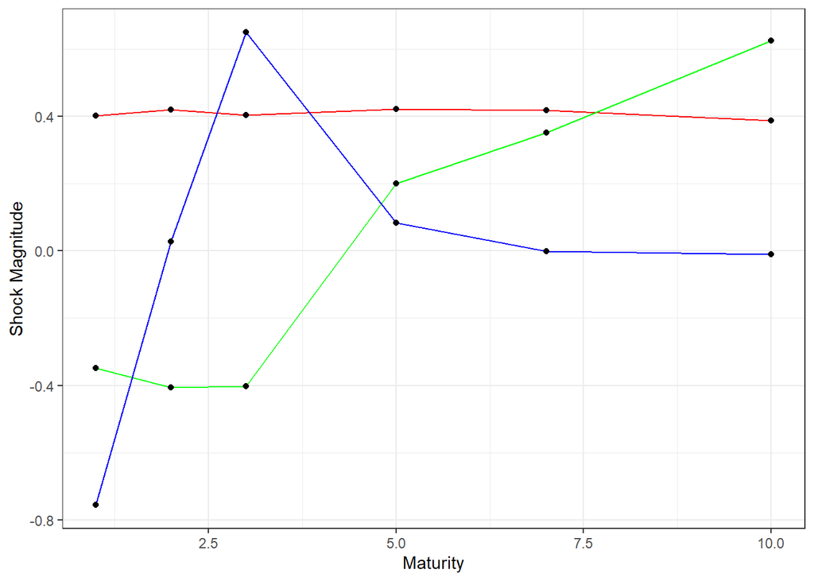

```r
# plot loading factors
library(ggplot2)
ggplot(data.frame(cbind(term=c(1,2,3,5,7,10),model$rotation[,1:3]))) +
  geom_line(aes(x=term,y=PC1),colour="red") + geom_point(aes(x=term,y=PC1)) +
  geom_line(aes(x=term,y=PC2),colour="green") + geom_point(aes(x=term,y=PC2)) +
  geom_line(aes(x=term,y=PC3),colour="blue") + geom_point(aes(x=term,y=PC3)) +
  xlab("Maturity") +
  ylab("Shock Magnitude") +
  theme_bw()
```

This visualization captures the factor loadings. The red line is the first principal component, and corresponds to a parallel move up and down in the level of the entire yield curve. The green line is the second principal component and is responsible for slope change and the third component displays the convexity.

We can plot the first two principal components as a scatterplot to see if there are any interesting features such as outliers or departures from normality.

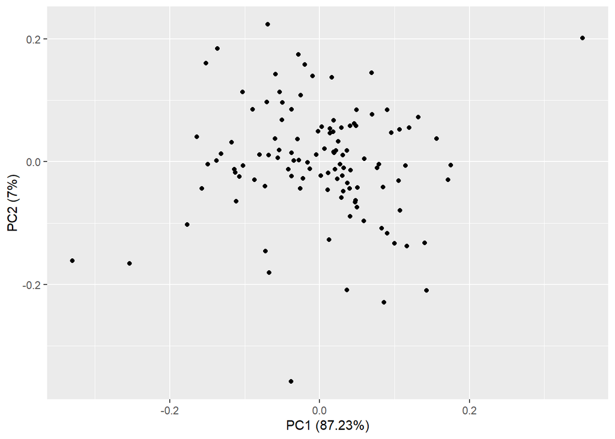

```r
library(ggfortify)
pca.plot <- autoplot(model, data = cor.returns, color = "Group")
pca.plot
```

There are a few outliers, but the first two principal components are shown to behave within the limits of multivariate normality.

Now that it has been shown that the PCA is functioning correctly, we can interpret our findings. In order to interpret each component, we can compute the correlations between the original data and each principal component in order to see which PCs are most correlated with the bonds.

```r
#cor.returns is the differenced dataset
#model$x is the PCA data

#take the correlation matrix to interpret the correlation between of the original variables and the PCs
comps.scaled <- pca.plot$data[,c(1:12)]
cor(comps.scaled[,3:8], comps.scaled[,c(1:2,9)])
```

```
##                          PC1   PC2      PC3
## us_govt_2y              0.92 -0.23 -0.32326
## us_govt_5y              0.96 -0.26  0.01158
## us_govt_10y             0.92 -0.26  0.27783
## fannie_4cpn             0.97  0.13  0.03551
## Mid_Yield_To_Convention 0.95  0.23 -0.00052
## fannie_5cpn             0.88  0.40 -0.00464
```

Resources

https://www.moodysanalytics.com/-/media/whitepaper/2014/2014-29-08-PCA-for-Yield-Curve-Modelling.pdf

https://insightr.wordpress.com/2017/04/14/american-bond-yields-and-principal-component-analysis/

https://arxiv.org/ftp/arxiv/papers/1911/1911.07288.pdf https://www.r-bloggers.com/2021/12/easy-interpretations-of-adf-test-in-r/

http://nakisa.org/bankr-useful-financial-r-snippets/principal-component-analysis/

https://research-doc.credit-suisse.com/docView?language=ENG&format=PDF&source_id=csplusresearchcp&document_id=1001969281&serialid=EVplkK6oNi2Oum067aSBs%2Bp%2F04%2F3pgbDBc%2B1pGHrQ0U%3D&cspId=null

http://www.bondeconomics.com/2018/12/primer-understanding-principal.html

https://online.stat.psu.edu/stat505/lesson/11/11.4